# Module 01: Interactive

Mette Langaas, editted by Bob O’Hara

2026-08-19

# Interactive lectures - problem set

You may of cause read through the problem set before the interactive lecture, but that is not a prerequisite. Solutions will be provided to the major part of the recommended exercises (but not to the R-part of this one).

**Hints and reminders are in bold**

Questions appear in blue.

**Some hints and answers are hidden away in a fold like this**

Well done, you found me!

The exam style questions are optional, but will be helpful for, well, the exam. They will also help you now to see if you understand the content.

# Core concept: Exponential family of distributions

[figure not shown]

(source: [Barry Rowlingson on Twitter. Sorry, X](https://x.com/geospacedman/status/1825255764719726607))

In this course we will look at models where the distribution of the response variable, $y_i$, can be written in the form of a *univariate exponential family*

$$f(y_i\mid \theta_i)=\exp \left( \frac{y_i
\theta_i-b(\theta_i)}{\phi}\cdot w_i + c(y_i, \phi, w_i) \right)$$

where

- $\theta_i$ is called the canonical parameter and is a parameter of interest (and will later be a function of covariates)
- $\phi$ is called a nuisance parameter: it is not of interest to us and thus a nuisance (plage)
- $w_i$ is a weight function, in most cases $w_i=1$
- b() and c() are known functions.

It can be shown that $\text{E}(Y_i)=b'(\theta_i)$ and $\text{Var}(Y_i)=b''(\theta_i)\cdot \frac{\phi}{w}$.

Slightly different ways of writing the exponential family exists, but we will use this version in our course.

## Theoretical questions (first hour)

We will work with the exponential family, but to make the notation easier for these tasks, we omit the $i$ subscript.

$$f(y \mid \theta)=\exp \left( \frac{y \theta-b(\theta)}{\phi}\cdot w +
c(y, \phi, w) \right)$$

### Problem 1:

Choose (discuss and then talk to lecturer/TA) if you will work on a) binomial, b) Poisson, c) univariate normal or d) gamma. For your choice:

- What process can produce a $Y$ that follows this distribution?
- Write down the probability mass function, f(x).
- Is the distribution a member of the exponential family?
- Identify $b$ and $c$ and show the connection with the mean and variance of $Y$.

**Hints for binomial distribution**

You may first use $n=1$ in the binomial (which then is called Bernoulli) - since that is much easier than a general $n$.

Hint: [TMA4245](https://wiki.math.ntnu.no/tma4245/tema/begreper/discrete) and nearly the same parameterization for showing the binomial is member of exponential ([watch this YouTube video for more](https://www.youtube.com/watch?v=7mNrsFr7P_A%3E)).

Also: $x = e^{\ln x}$

**Hints for Poisson distribution**

Hint: [TMA4245](https://wiki.math.ntnu.no/tma4245/tema/begreper/discrete) and first part of [Sannsynlighetsmaksimering](https://ntnu.cloud.panopto.eu/Panopto/Pages/Viewer.aspx?id=735b839f71ed49d99fc3af1f013345fb) might help

**Hints for Gamma distribution**

There are a few parameterisations for the Gamma. Try this one:

$$f(y)=\frac{1}{\Gamma(\nu)}
(\frac{\nu}{\mu})^{\nu} y^{\nu-1}\exp(-\frac{\nu}{\mu}y) \text{ for
}y>0$$

[Hint](https://wiki.math.ntnu.no/tma4245/tema/begreper/continuous)

**Link to Solutions**

Mettes solution to 1a-d: https://www.math.ntnu.no/emner/TMA4315/2017h/Module1ExponentialFamily.pdf

### Problem 2. Choose either alternative a or b.

Alternative a:

Prove that $\text{E}(Y_i)=b'(\theta_i)$ (where $b'(\theta_i)= \frac{d b(\theta_i)}{d \theta_i}$) and $\text{Var}(Y_i)=b''(\theta_i)\cdot \frac{\phi}{w}$.

**Hints for the strategy**

Take a sideways approach: differentiate with respect to $\theta$ (to get expressions involving $b'(\theta_i)$ & $b''(\theta_i)$), and integrate over $y$.

**Hints for the implementing the strategy**

Integration by parts, and investigate what $\int_{-\infty}^{\infty} \frac{df}{dy}dy$ is

Alternative b:

The following is a derivation of the mean and variance of an exponential family. Go through this derivation and specify why you go from one step to another.

[Derivation](https://www.math.ntnu.no/emner/TMA4315/2017h/M5ExpFamProofEVar.pdf)

## Exam questions with the exponential family – optional (covered above)

We have covered the Poisson and gamma in the problem sets above, but not the negative binomial (not in the core of the course)

### Exam December 2017, Problem 1a: Poisson regression

Consider a random variable $Y$. In our course we have considered the univariate exponential family having distribution (probability density function for continuous variables and probability mass function for discrete variables)

$$f(y)=\exp(\frac{y \theta -b(\theta)}{\phi}w + c(y,\phi,w))$$
where $\theta$ is called the *natural parameter* (or parameter of interest) and $\phi$ the *dispersion parameter*.

The Poisson distribution is a discrete distribution with probability mass function

$$f(y)=\frac{\lambda^{y}}{y!}\exp(- \lambda), \text{ for } y=0,1,...,$$

where $\lambda>0$.

**a**)

Show that the Poisson distribution is a univariate exponential family, and specify what are the elements of the exponential family $(\theta,\phi,b(\theta),w,c(y,\phi,w))$.

**Solution**

First,

$$\log( f(y|\theta)) = y \log\lambda - log(y!) - \lambda = \frac{y
\log\lambda - \lambda}{1} - log(y!)$$
Which might look odd, but means we can easily pick out the terms:
$$\begin{align}
\theta &= \log \lambda \\
\phi &= 1 \\
b(\theta) &= \lambda = e^\theta \\
w &= 1 \\
c(y,\phi,w) &= - log(y!)
\end{align}$$

What is the connection between $\text{E}(Y)$ and the elements of the exponential family?

**Solution**

$\text{E}(Y_i)=b'(\theta_i)$

What is the connection between $\text{Var}(Y)$ and the elements of the exponential family?

**Solution**

$\text{Var}(Y_i)=b''(\theta_i)\cdot \frac{\phi}{w}$.

Use these connections to derive the mean and variance for the Poisson distribution.

**Solution**

From above,

$b(\theta) = \lambda = e^\theta$

so $b'(\theta) = e^\theta = \lambda$ and $b''(\theta) = e^\theta = \lambda$

### Exam 2012, Problem 3: Precipitation in Trondheim, amount

Remark: the text is slightly modified from the original exam since we parameterized the gamma as in our textbook.

We want to model the amount of daily precipitation given that it *is* precipitation, and denote this quantity $Y$. It is common to model $Y$ as a gamma distributed random variable, $Y \sim Gamma(\nu,\mu)$, with density

$$f_Y(y) = \frac{1}{\Gamma(\nu)}
\left(\frac{\nu}{\mu}\right)^{\nu} y^{\nu-1}\exp\left(-\frac{\nu}{\mu} y
\right)$$

In this problem we consider $N$ observations, each gamma distributed with $Y_i \sim Gamma(\nu, \mu_i)$ (remark: common $\nu$). Here $\nu$ is considered to be a known nuisance parameter, and the $\mu_i$s are unknown.

a) Show that the gamma distribution function is member of the exponential family when $\mu_i$ is the parameter of interest.

Use this to find expressions for the expected value and the variance of $Y_i$, in terms of $(\nu,\mu_i)$, and interpret $\nu$.

### Exam 2010, Problem 2: Negative binomial distribution

The probability density function for a negative binomial random variable is
$$f_y(y; p, r) = \frac{\Gamma(y +
r)}{y! \Gamma(r)} (1-p)^r p^y$$
for $y = 0,1,2,\ldots,$, $r>0$ and $p \in (0,1)$, and where $\Gamma()$ denotes the gamma function. (There are also other parameterizations of the negative binomial distributions, but use this for now.)

a) Show that the negative binomial distribution is an exponential family. You can in this question consider $r$ as a known constant.

**Solution**

$$\begin{align}
\log f(y|r, p) &= \log \Gamma(y + r) - \log y! - \log \Gamma(r) + r
\log(1-p) + y \log p \\
&= \frac{y \log p + r \log(1-p)}{1} + \log \Gamma(y + r) - \log y! -
\log \Gamma(r)
\end{align}$$
So

$$\begin{align}
\theta &= \log p, so p=e^\theta \\
\phi &= 1 \\
b(\theta) &= -r \log(1-p) = -r \log(1-e^\theta)\\
w &= 1 \\
c(y,\phi,w) &= \log \Gamma(y + r) - \log y! - \log \Gamma(r)
\end{align}$$

b) Use the general formulas for a exponential family to show that $\text{E}(Y)=\mu=r\frac{p}{1-p}$ and $\text{Var}(Y)=\mu \frac{1}{1-p}$.

**Solution**

Starting with $E(y) = b'(\theta)$, where $b(\theta)=-r \log(1-\theta) = -r \log(A)$ (with $A=1-e^\theta$)

$$\begin{align}
E(y) &= \frac{d (-r \log(1-e^\theta))}{d\theta} =-r \frac{d
\log(A)}{dA}\frac{d A}{d\theta} \\
&=-r \frac{1}{1-e^\theta} (-e^\theta) \\
&=r \frac{e^\theta}{1-e^\theta} \\
&= r \frac{p}{1-p}
\end{align}$$

And now to show that $\text{Var}(Y)=\mu \frac{1}{1-p}$, using $\text{Var}(Y_i)=b''(\theta_i)\cdot \frac{\phi}{w}$. Note that $\phi=w=1$, so

$$\begin{align}
\text{Var}(y) &= \frac{d^2 (-r \log(1-e^\theta))}{d\theta^2} \\
&=r \frac{d \frac{e^\theta}{1-e^\theta}}{d\theta} \\
&=r \frac{(1-e^\theta ) e^\theta - e^\theta
(-e^\theta)}{(1-e^\theta)^2} \\
&= r \frac{e^\theta}{1-e^\theta}
\frac{1-e^\theta+e^\theta}{1-e^\theta} \\
&= \mu \frac{1}{1-p} \\
\end{align}$$

## Focus on R-related topics (second hour)

## R, Rstudio, CRAN and GitHub - and R Markdown

#### What is R?

https://www.r-project.org/about.html

#### What is Rstudio?

https://www.rstudio.com/products/rstudio/

#### What is an R package?

http://r-pkgs.had.co.nz (We will make an R package in the exercise part of this course.)

#### What is CRAN?

https://cran.uib.no/

#### What is GitHub and Bitbucket?

Do we need GitHub or Bitbucket in our course? https://www.youtube.com/watch?v=w3jLJU7DT5E and https://techcrunch.com/2012/07/14/what-exactly-is-github-anyway/

#### What is R Markdown?

http://r4ds.had.co.nz/r-markdown.html

#### What is `knitr`?

https://yihui.name/knitr/

#### What is R Shiny?

https://shiny.rstudio.com/

(In the statistics group we will build R Shiny app for the thematic pages for our TMA4240/TMA4245/ST1101/ST1201/ST0103 introductory courses, so if you have ideas for cool graphical presentation please let us know - we have some economical resources available for help from master students in statistics! Also ideas for this GLM course is or interest!)

The IMF R Shiny server is here: https://shiny.math.ntnu.no/ (not anything there now, but a lot more soooon).

(Remember the test you did to brush up on R programming? https://tutorials.shinyapps.io/04-Programming-Basics/#section-welcome This was made with a combination of the R package `learnr` and a shiny server.)

## Explore R Markdown in Rstudio

Quotations from https://rmarkdown.rstudio.com/authoring_quick_tour.html:

- Creating documents with R Markdown starts with an .Rmd file that contains a combination of markdown (content with simple text formatting) and R code chunks.
- The .Rmd file is fed to knitr, which executes all of the R code chunks and creates a new markdown (.md) document which includes the R code and it’s output.
- The markdown file generated by knitr is then processed by pandoc which is responsible for creating a finished web page, PDF, MS Word document, slide show, handout, book, dashboard, package vignette or other format.

The module pages (you are reading the Module 1 page now), are written using R Markdown. To work with the module pages you either copy-paste snippets of R code from the module page over in your editor window in Rstudio, or copy the Rmd-version of the module page (1Intro.Rmd) into your Rstudio editor window (then you can edit directly in Rmarkdown document - to make it into your personal copy).

If you choose the latter: To compile the R code we use `knitr` (termed “knit”) to produce a html-page you press “knit” in menu of the editor window, but first you need to install packages: `rmarkdown` and `devtools` (from CRAN). For the module pages the needed R packages will always be listed in the end of the module pages.

If you want to learn more about the R Markdown (that you may use for the compulsory exercises) this is a good read:

- http://r4ds.had.co.nz/r-markdown.html (Chapter 27: R Markdown from the “R for Data Science” book), and
- the Rstudio cheat sheet on R Markdown is here: https://www.rstudio.com/wp-content/uploads/2016/03/rmarkdown-cheatsheet-2.0.pdf.

Then you see that you can make a pdf-file in addition to a html-file (for your reports you may choose either). To make the pdf-file you need latex to be installed on your machine.

## Not using R Markdown, but only R code?

If you only want to extract the R code from a R Markdown file you may do that using the function `purl` from library `knitr`. To produce a file “1Intro.R” from this “1Intro.Rmd” file:

```r
library(knitr)
purl("https://www.math.ntnu.no/emner/TMA4315/2018h/1Intro.Rmd")
```

The file will then be saved in your working directory, that you see with `getwd()`.

## R packages

And to work with either the 1Intro.R or 1Intro.Rmd file you will have to first install the following libraries:

```r
install.packages(c("rmarkdown","gamlss.data","tidyverse","ggpubr","investr","lme4"))
```

For the subsequent module pages this information will be available in the end of the page.

## The Munich Rent Index Data set

We will use this data set when working with multiple linear regression (next module), so this is a good way to start to know the data set and the ggplot functions, which can be installed together with a suite of useful libraries from `tidyverse`.

A version of the Munich Rent Index data is available as `rent99` in library `gamlss.data` from CRAN.

```r
library(gamlss.data)
library(ggplot2)
```

Get to know the `rent` data.

```r
ds=rent99
colnames(ds)
```

```
## [1] "rent"     "rentsqm"  "area"     "yearc"    "location" "bath"     "kitchen"
## [8] "cheating" "district"
```

```r
dim(ds)
```

```
## [1] 3082    9
```

```r
summary(ds)
```

```
##       rent            rentsqm             area            yearc      location
##  Min.   :  40.51   Min.   : 0.4158   Min.   : 20.00   Min.   :1918   1:1794
##  1st Qu.: 322.03   1st Qu.: 5.2610   1st Qu.: 51.00   1st Qu.:1939   2:1210
##  Median : 426.97   Median : 6.9802   Median : 65.00   Median :1959   3:  78
##  Mean   : 459.44   Mean   : 7.1113   Mean   : 67.37   Mean   :1956
##  3rd Qu.: 559.36   3rd Qu.: 8.8408   3rd Qu.: 81.00   3rd Qu.:1972
##  Max.   :1843.38   Max.   :17.7216   Max.   :160.00   Max.   :1997
##  bath     kitchen  cheating    district
##  0:2891   0:2951   0: 321   Min.   : 113
##  1: 191   1: 131   1:2761   1st Qu.: 561
##                             Median :1025
##                             Mean   :1170
##                             3rd Qu.:1714
##                             Max.   :2529
```

Then, head for plotting with `ggplot` but first take a quick look at the `ggplot2` library:

- Grolemund and Hadwick (2017): “R for Data Science”, Chapter 3: Visualisation: http://r4ds.had.co.nz/data-visualisation.html

Before you continue you should have read the start of the Visualisation chapter that explains the ggplot grammar. Yes, you start with creating the coordinate system with `ggplot` and then add layers. What does the following words mean: mapping, aesthetic, geom function mean in the `ggplot` setting?

- The Rstudio cheat sheet on ggplot2 is here: https://www.rstudio.com/wp-content/uploads/2016/11/ggplot2-cheatsheet-2.1.pdf

First, look at plotting `rentsqm` for different values of `location` - with panels of scatter plots and with boxplots

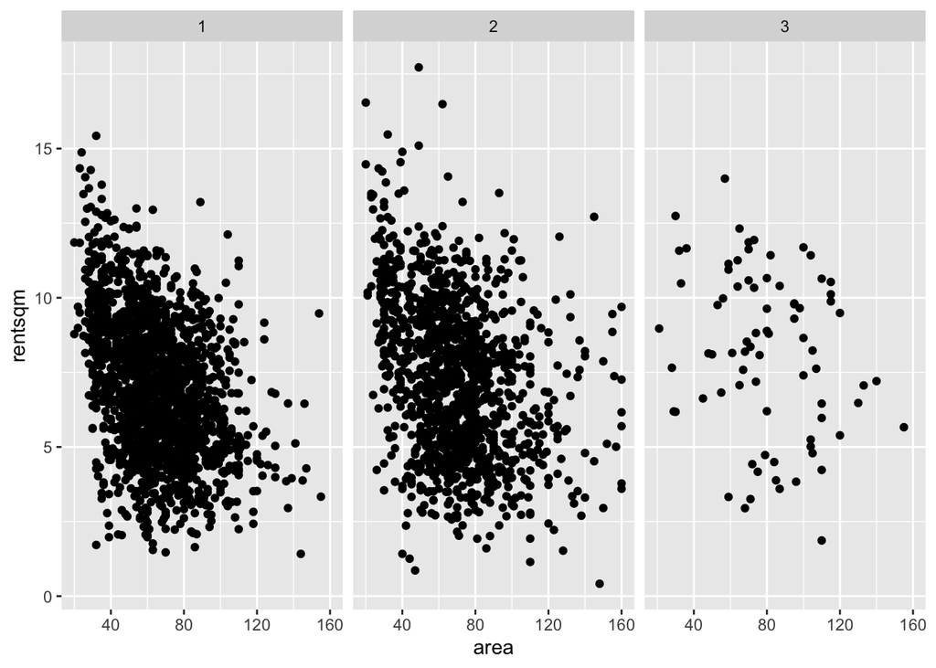

```r
ggplot(data=ds)+
  geom_point(mapping=aes(area,rentsqm))+
  facet_wrap(~location,nrow=1)
```

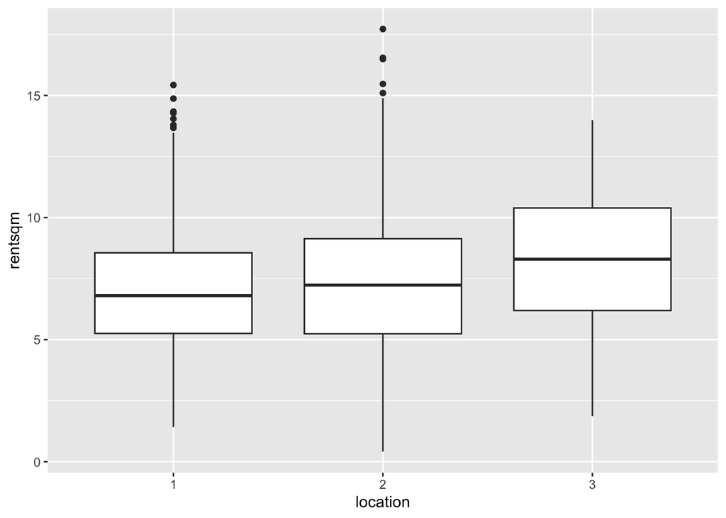

```r
ggplot(data = ds, mapping = aes(x = location, y = rentsqm)) +
  geom_boxplot()
```

So, location matters.

But, should we use `rent` or `rentsqm` as response?

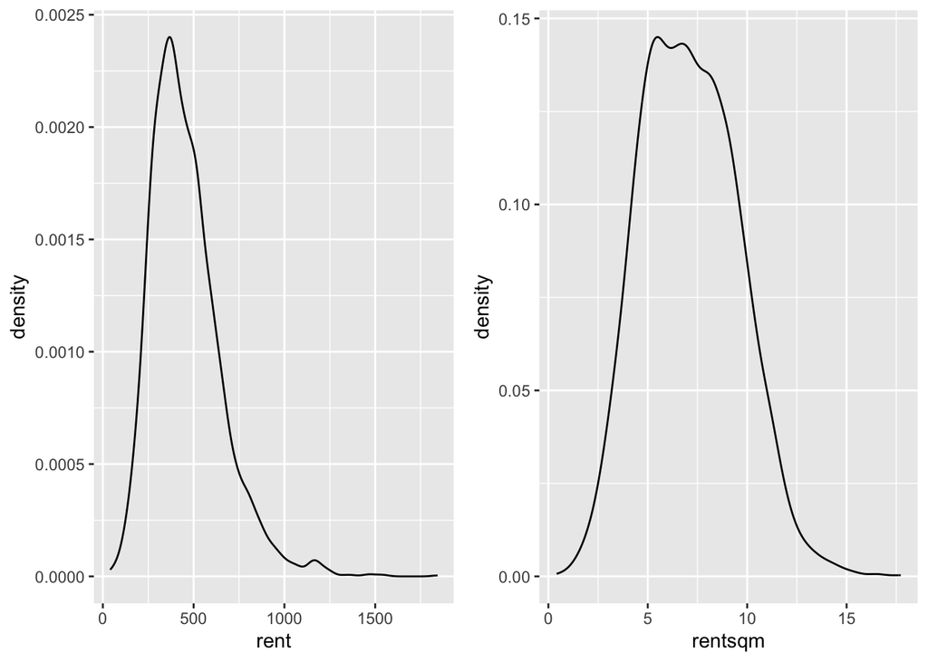

```r
library(ggpubr)
plot1 <- ggplot(data=ds) +
  geom_density(mapping=aes(rent),kernel="gaussian")
plot2 <- ggplot(data=ds) +
  geom_density(mapping=aes(rentsqm),kernel="gaussian")
ggarrange(plot1, plot2, ncol=2)
```

So, which response will we use? And, what if we would include `area` as covariate? I have plotted two plots together below, more on mixing graphs on the same page (we need ggprbr, gridExtra and cowplot packages) https://www.r-bloggers.com/ggplot2-easy-way-to-mix-multiple-graphs-on-the-same-page/

Relationship between `rent` or `rentsqm` and `area`

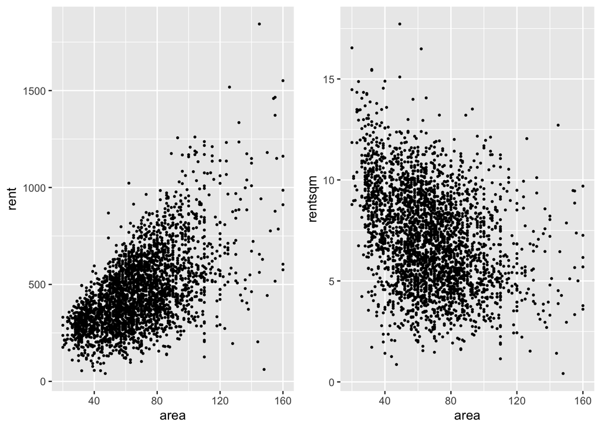

```r
plot1 <- ggplot(data=ds,aes(area,rent))+
  geom_point(mapping=aes(area,rent),size=0.5)
plot2 <- ggplot(data=ds)+
  geom_point(mapping=aes(area,rentsqm),size=0.5)
ggarrange(plot1, plot2, ncol=2)
```

So, if we include area as a covariate, we may look at residuals when using `rent` or `rentsqm`. More about diagnostic plots in Module 2 - but - which plot below looks more random?

```r
lm.rent=lm(rent~area,data=ds)
summary(lm.rent)
```

```
##
## Call:
## lm(formula = rent ~ area, data = ds)
##
## Residuals:
##     Min      1Q  Median      3Q     Max
## -786.63 -104.88   -5.69   95.93 1009.68
##
## Coefficients:
##             Estimate Std. Error t value Pr(>|t|)
## (Intercept) 134.5922     8.6135   15.63   <2e-16 ***
## area          4.8215     0.1206   39.98   <2e-16 ***
## ---
## Signif. codes:  0 '***' 0.001 '**' 0.01 '*' 0.05 '.' 0.1 ' ' 1
##
## Residual standard error: 158.8 on 3080 degrees of freedom
## Multiple R-squared:  0.3417, Adjusted R-squared:  0.3415
## F-statistic:  1599 on 1 and 3080 DF,  p-value: < 2.2e-16
```

```r
lm.rentsqm=lm(rentsqm~area,data=ds)
summary(lm.rentsqm)
```

```
##
## Call:
## lm(formula = rentsqm ~ area, data = ds)
##
## Residuals:
##     Min      1Q  Median      3Q     Max
## -6.9622 -1.5737 -0.1102  1.5861  9.9674
##
## Coefficients:
##             Estimate Std. Error t value Pr(>|t|)
## (Intercept)  9.46883    0.12426   76.20   <2e-16 ***
## area        -0.03499    0.00174  -20.11   <2e-16 ***
## ---
## Signif. codes:  0 '***' 0.001 '**' 0.01 '*' 0.05 '.' 0.1 ' ' 1
##
## Residual standard error: 2.291 on 3080 degrees of freedom
## Multiple R-squared:  0.1161, Adjusted R-squared:  0.1158
## F-statistic: 404.5 on 1 and 3080 DF,  p-value: < 2.2e-16
```

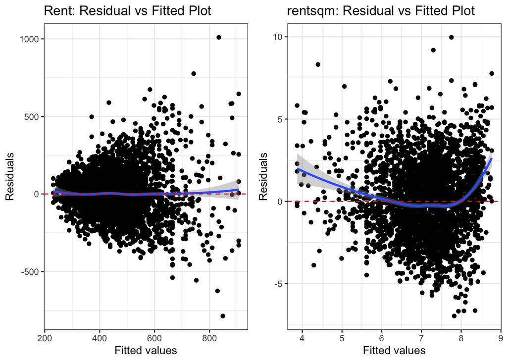

```r
p1<-ggplot(lm.rent, aes(.fitted, .resid))+geom_point()
p1<-p1+stat_smooth(method="loess")+geom_hline(yintercept=0, col="red", linetype="dashed")
p1<-p1+xlab("Fitted values")+ylab("Residuals")
p1<-p1+ggtitle("Rent: Residual vs Fitted Plot")+theme_bw()
p2<-ggplot(lm.rentsqm, aes(.fitted, .resid))+geom_point()
p2<-p2+stat_smooth(method="loess")+geom_hline(yintercept=0, col="red", linetype="dashed")
p2<-p2+xlab("Fitted values")+ylab("Residuals")
p2<-p2+ggtitle("rentsqm: Residual vs Fitted Plot")+theme_bw()
ggarrange(p1, p2, ncol=2)
```

## Combining exercise 1 and 2:

Choose one of the distributions you studied earlier (binomial, Poisson, normal or gamma), and write a R-markdown document answering the questions on requirements, f(x), f(x) as exponential family and mean and variance. Also add R-code to plot f(x) and F(x) for a given set of parameters - and add the mean as a vertical line - using the ggplot library.

Submit your Rmd document to the lecturer (email) - so it can be added to this module solutions, or make your own github repository and email the link to your repo to be added to this module page.

# Further reading

- Grolemund and Hadwick (2017): “R for Data Science”, http://r4ds.had.co.nz
- Xie, Allaire and Grolemund (2018): “R Markdown — the definitive guide”, https://bookdown.org/yihui/rmarkdown/
- Hadwick (2009): [“ggplot2: Elegant graphics for data analysis” textbook](https://link.springer.com/book/10.1007%2F978-0-387-98141-3).
- Wilkinson (2005): [The grammar of graphics](https://www.springer.com/gp/book/9780387245447). The theory behind the ggplot2 package universe.
- If you want to see more of the powers of ggplot, combined with a nice story: https://www.andrewheiss.com/blog/2017/08/10/exploring-minards-1812-plot-with-ggplot2/
- R-bloggers: https://https://www.r-bloggers.com/ is a good place to look for tutorials.
- Stack Overflow: https://stackoverflow.com/ is a good place to look for answers to your R questions (but also try the GLM teaching team)
- And [this site](https://www.google.com/) can sometimes be helpful.